# 5. Фреквенцијска анализа и секторски дијаграми

У овој лекцији ћеш научити:

1. како да извршиш *фреквенцијску анализу* низа података (што је једно компликовано име за једну веома једноставну и корисну ствар); и
2. како да прикажеш заступљеност неких величина на секторском дијаграму.

## 5.1. Фреквенцијска анализа низа података

*Фреквенцијска анализа* низа података се своди на то да се преброје подаци у низу и да се на основу тако добијених *фреквенција података* покуша доћи до неког закључка (реч *фреквенција* значи "учесталост"). На пример, у једном разреду има 30 ученика и њихове оцене из информатике су дате у следећем низу:

```python
oceneInf = [3, 4, 5, 4, 5, 3, 4, 5, 2, 4, 5, 4, 5, 4, 2, 3, 1, 4, 5, 4, 3, 2, 3, 4, 5, 4, 5, 5, 4, 3]
```

Фреквенцијска анализа овог низа се своди на то да се утврди колико има петица, четворки, тројки, двојки и јединица у том разреду. Уместо да то урадимо ручно (рецимо, да направимо табелицу па да "лупамо рецке"), пустићемо Пајтон да то уради за нас. Пајтон има уграђену функцију `count` која може да преброји колико пута се у некој листи јавља неки елемент:

```python
ocena5 = oceneInf.count(5)
ocena4 = oceneInf.count(4)
ocena3 = oceneInf.count(3)
ocena2 = oceneInf.count(2)
ocena1 = oceneInf.count(1)
print("Ocene u razredu su raspodeljene kako sledi:")
print("Ocenu 5 ima", ocena5, "ucenika")
print("Ocenu 4 ima", ocena4, "ucenika")
print("Ocenu 3 ima", ocena3, "ucenika")
print("Ocenu 2 ima", ocena2, "ucenika")
print("Ocenu 1 ima", ocena1, "ucenika")
```

```
Ocene u razredu su raspodeljene kako sledi:
Ocenu 5 ima 9 ucenika
Ocenu 4 ima 11 ucenika
Ocenu 3 ima 6 ucenika
Ocenu 2 ima 3 ucenika
Ocenu 1 ima 1 ucenika
```

За сваку оцену смо одредили колико се пута појавила у листи и добили смо податке у *апсолутним износима*.

Ако желимо да одредимо *релативне односе* бројева оцена, добијене бројеве ћемо исказати у процентима:

```python
ukupno = len(oceneInf)
procenat5 = 100.0 * ocena5 / ukupno
procenat4 = 100.0 * ocena4 / ukupno
procenat3 = 100.0 * ocena3 / ukupno
procenat2 = 100.0 * ocena2 / ukupno
procenat1 = 100.0 * ocena1 / ukupno
print("Ocene u razredu su raspodeljene kako sledi:")
print("Ocenu 5 ima ", round(procenat5, 2), "% ucenika", sep="")
print("Ocenu 4 ima ", round(procenat4, 2), "% ucenika", sep="")
print("Ocenu 3 ima ", round(procenat3, 2), "% ucenika", sep="")
print("Ocenu 2 ima ", round(procenat2, 2), "% ucenika", sep="")
print("Ocenu 1 ima ", round(procenat1, 2), "% ucenika", sep="")
```

```
Ocene u razredu su raspodeljene kako sledi:
Ocenu 5 ima 30.0% ucenika
Ocenu 4 ima 36.67% ucenika
Ocenu 3 ima 20.0% ucenika
Ocenu 2 ima 10.0% ucenika
Ocenu 1 ima 3.33% ucenika
```

Дакле, фреквенцијска анализа нам даје вредности у *конкретном износу* (рецимо, у разреду има 9 петица, 11 четворки и тако даље). Ако ове податке представимо процентима добијамо податке који нам говоре о заступљености оцена у *релативним* односима.

Тако, у овом разреду има 30% петица (9 / 30 = 30%), 36,67% четворки (11 / 30 = 36,67%), 20% тројки (6 / 30 = 20%), 10% двојки (3 / 30 = 10%) и 3,33% јединица (1 / 30 = 3,33%).

## 5.2. Секторски дијаграми

У ситуацијама када се приказује колико процената које компоненте учествује у саставу неке целине погодно је податке приказати *секторским дијаграмом* који представља круг исечен на исечке попут пице. Круг тада представља целину (100%), док исечци представљају компоненте које учествују у целини исказане у процентима.

На пример, оцене из информатике су у једном разреду са 30 ученика расподељене овако:

| Оцена | Заступљеност оцене |
| --- | --- |
| 5 | 9 |
| 4 | 11 |
| 3 | 6 |
| 2 | 3 |
| 1 | 1 |

Податке из ове табеле ћемо илустровати секторским дијаграмом. Прво ћемо увести библиотеку:

```python
import matplotlib.pyplot as plt
```

Онда ћемо податке записати помоћу два низа овако:

```python
frekvencije = [9,   11,  6,   3,   1]
ocene       = ["5", "4", "3", "2", "1"]
```

И сада можемо да пређемо на представљање података дијаграмом. Функција која податке представља секторским дијаграмом се зове `pie` зато што се у америчком сленгу секторски дијаграми зову *pie charts* = "тортасти дијаграми". Први аргумент представља низ вредности, док се другим задају ознаке (енгл. *label* = ознака:):

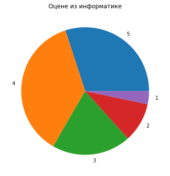

```python
plt.figure(figsize=(6,6))
plt.pie(frekvencije, labels=ocene)
plt.title("Оцене из информатике")
plt.show()
plt.close()
```

Ако желимо да нагласимо број петица у разреду можемо одговарајући сектор да "измакнемо" мало из средишта. То се постиже аргументом `explode` функције `pie` који за сваки податак у низу каже колико треба да га измакнемо из средишта (0 = не треба изместити сектор из средишта дијаграма; што је већи број, то је и измештање веће).

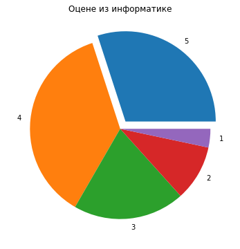

```python
frekvencije = [9,   11,  6,   3,   1]
ocene       = ["5", "4", "3", "2", "1"]
izmestanje  = [0.1, 0,   0,   0,   0]
plt.figure(figsize=(6,6))
plt.pie(frekvencije, labels=ocene, explode=izmestanje)
plt.title("Оцене из информатике")
plt.show()
plt.close()
```

Као други пример посматрајмо структуру наше атмосфере. Наша атмосфера је смеша разних гасова, а сув ваздух има следећи састав:

| Гас | Заступљеност (%) |
| --- | --- |
| Азот | 78,08 |
| Кисеоник | 20,94 |
| Аргон | 0,93 |
| Угљен диоксид | 0,05 |

Важно је напоменути да *ово није тачан састав наше атмосфере:* у њој има и других гасова, али у траговима (како то хемичари воле да кажу) па они нису приказани у табели.

Структуру атмосфере ћемо представити секторским дијаграмом овако:

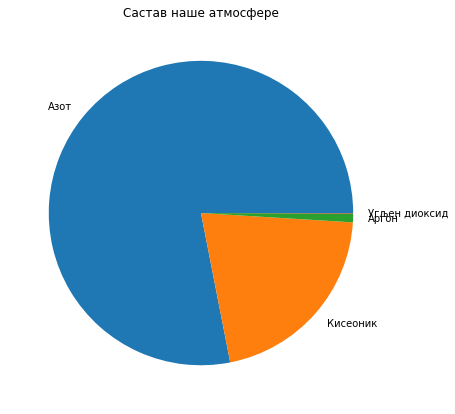

```python
procenti = [78.08,  20.94,      0.93,    0.05]
oznake   = ["Азот", "Кисеоник", "Аргон", "Угљен диоксид"]
plt.figure(figsize=(7,7))
plt.pie(procenti, labels=oznake)
plt.title("Састав наше атмосфере")
plt.show()
plt.close()
```

Опет наилазимо на проблем: ознаке за последња два податка су се преклопиле јер се ради о веома уском секторима. Да бисмо решили проблем можемо још више да повећамо дијаграм, а можемо пробати и да последња два "мала" сектора "измакнемо" из средишта, овако:

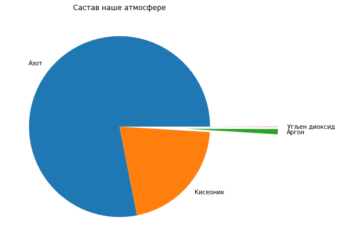

```python
procenti   = [78.08,  20.94,      0.93,    0.05]
oznake     = ["Азот", "Кисеоник", "Аргон", "Угљен диоксид"]
izmestanje = [0,      0,          0.75,    0.75]
plt.figure(figsize=(7,7))
plt.pie(procenti, labels=oznake, explode=izmestanje)
plt.title("Састав наше атмосфере")
plt.show()
plt.close()
```